# Titanic Survival Analysis: Decomposing the Class-Survival Gap into Access and Constraint Mechanisms

Author

CLI Copilot

Published

January 23, 2026

## Executive Summary

This analysis addresses a critical research question: **How much of the class–survival gap is explained by access and constraints rather than priority rules?** The Titanic disaster provides a unique natural experiment where we can examine whether observable differences in survival rates across passenger classes reflect differential access to survival resources, physical constraints on escape, or explicit prioritization policies. This report outlines a methodological framework to decompose the class-survival relationship into measurable components.

## 1. Research Question & Analytical Framework

### 1.1 Understanding the Research Question

The survival patterns during the Titanic disaster are known to differ dramatically by passenger class. However, this disparity could arise from multiple distinct mechanisms:

1. **Priority Rules**: Official policies (e.g., “women and children first”) that explicitly granted some groups preferential evacuation
2. **Access Constraints**: Physical and logistical factors that affected some groups’ ability to reach lifeboats (e.g., cabin location, gate barriers)
3. **Information Access**: Awareness of the disaster and lifeboat locations

Our analytical goal is to isolate which mechanism explains the largest portion of the class-survival relationship. We do this by examining patterns in demographic composition, spatial distribution, and conditional survival probabilities across classes.

### 1.2 Analytical Strategy

We will employ the following approach:

1. **Descriptive Analysis**: Document the raw survival gap by class and basic demographics
2. **Decomposition Analysis**: Examine whether the class gap persists after controlling for:
   - Gender composition (proxy for priority rules)
   - Age distribution (proxy for vulnerability/access constraints)
   - Family structure (proxy for coordination and evacuation logistics)
3. **Mechanism-Specific Tests**: Assess whether patterns align with access/constraint hypotheses versus pure priority
4. **Quantitative Attribution**: Estimate the proportion of the class gap explained by each mechanism

## 2. Data Preparation and Exploration

### 2.1 Loading and Initial Exploration

```r
library(tidyverse)
library(knitr)
library(ggplot2)
library(scales)

# Load training data
titanic_raw <- read_csv("../../data/train.csv")

# Display basic structure
head(titanic_raw)
```

```
# A tibble: 6 × 12
  PassengerId Survived Pclass Name    Sex     Age SibSp Parch Ticket  Fare Cabin
        <dbl>    <dbl>  <dbl> <chr>   <chr> <dbl> <dbl> <dbl> <chr>  <dbl> <chr>
1           1        0      3 Braund… male     22     1     0 A/5 2…  7.25 <NA>
2           2        1      1 Cuming… fema…    38     1     0 PC 17… 71.3  C85
3           3        1      3 Heikki… fema…    26     0     0 STON/…  7.92 <NA>
4           4        1      1 Futrel… fema…    35     1     0 113803 53.1  C123
5           5        0      3 Allen,… male     35     0     0 373450  8.05 <NA>
6           6        0      3 Moran,… male     NA     0     0 330877  8.46 <NA>
# ℹ 1 more variable: Embarked <chr>
```

```r
dim(titanic_raw)
```

```
[1] 891  12
```

We begin by loading the Titanic training dataset, which contains passenger information including survival outcome (the dependent variable), class, demographics, and family relationships. Understanding the structure and completeness of this data is essential before proceeding with any analysis, as missing values will affect our ability to examine specific mechanisms.

### 2.2 Data Quality Assessment

```r
# Check for missing values
missing_summary <- titanic_raw %>%
  summarise(across(everything(), ~sum(is.na(.)))) %>%
  pivot_longer(everything(), names_to = "Variable", values_to = "Missing_Count") %>%
  mutate(Total_N = nrow(titanic_raw),
         Missing_Pct = round(100 * Missing_Count / Total_N, 2)) %>%
  arrange(desc(Missing_Count))

knitr::kable(missing_summary, caption = "Missing Values by Variable")
```

Missing Values by Variable

| Variable | Missing_Count | Total_N | Missing_Pct |
| --- | --- | --- | --- |
| Cabin | 687 | 891 | 77.10 |
| Age | 177 | 891 | 19.87 |
| Embarked | 2 | 891 | 0.22 |
| PassengerId | 0 | 891 | 0.00 |
| Survived | 0 | 891 | 0.00 |
| Pclass | 0 | 891 | 0.00 |
| Name | 0 | 891 | 0.00 |
| Sex | 0 | 891 | 0.00 |
| SibSp | 0 | 891 | 0.00 |
| Parch | 0 | 891 | 0.00 |
| Ticket | 0 | 891 | 0.00 |
| Fare | 0 | 891 | 0.00 |

Data quality directly impacts our ability to test mechanisms. Missing values in age, cabin location, and embarked port will limit our analysis of physical access constraints. We document these limitations before proceeding, as they constrain which mechanism-specific hypotheses we can rigorously test.

### 2.3 Variable Preparation

```r
titanic <- titanic_raw %>%
  # Create class labels for clarity
  mutate(
    Class = factor(Pclass, levels = 1:3, labels = c("1st Class", "2nd Class", "3rd Class")),
    Survived = factor(Survived, levels = 0:1, labels = c("No", "Yes")),
    Sex = factor(Sex),
    # Create age groups for stratified analysis
    Age_Group = case_when(
      is.na(Age) ~ "Missing",
      Age < 13 ~ "Child (<13)",
      Age < 18 ~ "Teen (13-17)",
      Age < 65 ~ "Adult (18-64)",
      TRUE ~ "Elderly (65+)"
    ),
    Age_Group = factor(Age_Group,
                       levels = c("Child (<13)", "Teen (13-17)", "Adult (18-64)",
                                 "Elderly (65+)", "Missing")),
    # Family size indicator
    Family_Size = SibSp + Parch + 1,
    Traveling_Alone = (Family_Size == 1),
    # Embarked port (with handling for missing)
    Embarked = factor(Embarked),
    # Cabin information as access proxy
    Has_Cabin_Info = !is.na(Cabin)
  ) %>%
  select(-Pclass, -Ticket, -Cabin) # Remove redundant/unused variables

glimpse(titanic)
```

```
Rows: 891
Columns: 14
$ PassengerId     <dbl> 1, 2, 3, 4, 5, 6, 7, 8, 9, 10, 11, 12, 13, 14, 15, 16,…
$ Survived        <fct> No, Yes, Yes, Yes, No, No, No, No, Yes, Yes, Yes, Yes,…
$ Name            <chr> "Braund, Mr. Owen Harris", "Cumings, Mrs. John Bradley…
$ Sex             <fct> male, female, female, female, male, male, male, male, …
$ Age             <dbl> 22, 38, 26, 35, 35, NA, 54, 2, 27, 14, 4, 58, 20, 39, …
$ SibSp           <dbl> 1, 1, 0, 1, 0, 0, 0, 3, 0, 1, 1, 0, 0, 1, 0, 0, 4, 0, …
$ Parch           <dbl> 0, 0, 0, 0, 0, 0, 0, 1, 2, 0, 1, 0, 0, 5, 0, 0, 1, 0, …
$ Fare            <dbl> 7.2500, 71.2833, 7.9250, 53.1000, 8.0500, 8.4583, 51.8…
$ Embarked        <fct> S, C, S, S, S, Q, S, S, S, C, S, S, S, S, S, S, Q, S, …
$ Class           <fct> 3rd Class, 1st Class, 3rd Class, 1st Class, 3rd Class,…
$ Age_Group       <fct> Adult (18-64), Adult (18-64), Adult (18-64), Adult (18…
$ Family_Size     <dbl> 2, 2, 1, 2, 1, 1, 1, 5, 3, 2, 3, 1, 1, 7, 1, 1, 6, 1, …
$ Traveling_Alone <lgl> FALSE, FALSE, TRUE, FALSE, TRUE, TRUE, TRUE, FALSE, FA…
$ Has_Cabin_Info  <lgl> FALSE, TRUE, FALSE, TRUE, FALSE, FALSE, TRUE, FALSE, F…
```

We prepare the data by creating interpretable categorical variables. Class becomes a labeled factor for clarity. Age is grouped to allow examination of whether “women and children first” policy effects are observable. Family size variables help test whether evacuation logistics (coordinating family members) created differential access. Cabin information availability serves as a proxy for explicit passenger tracking versus implicit constraints.

## 3. Descriptive Analysis: The Class-Survival Gap

### 3.1 Raw Survival Rates by Class

```r
# Calculate survival proportions by class
survival_by_class <- titanic %>%
  group_by(Class) %>%
  summarise(
    N = n(),
    Survived_Count = sum(Survived == "Yes"),
    Survival_Rate = round(100 * Survived_Count / N, 2),
    .groups = "drop"
  )

knitr::kable(survival_by_class,
             caption = "Raw Survival Rates by Passenger Class")
```

Raw Survival Rates by Passenger Class

| Class | N | Survived_Count | Survival_Rate |
| --- | --- | --- | --- |
| 1st Class | 216 | 136 | 62.96 |
| 2nd Class | 184 | 87 | 47.28 |
| 3rd Class | 491 | 119 | 24.24 |

This table documents the baseline disparity: survival rates vary substantially across passenger classes. This raw gap is our dependent variable—what we seek to explain through the lens of access constraints versus priority rules.

### 3.2 Visualizing the Class-Survival Gap

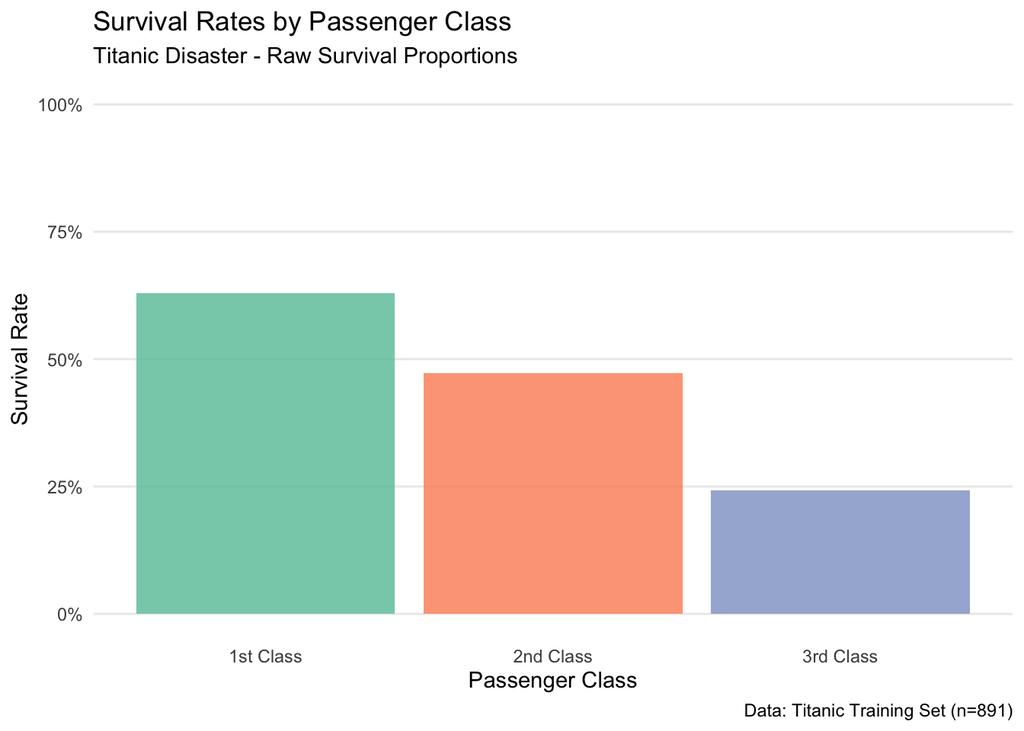

```r
ggplot(survival_by_class, aes(x = Class, y = Survival_Rate, fill = Class)) +
  geom_col(alpha = 0.8, show.legend = FALSE) +
  scale_fill_brewer(palette = "Set2") +
  scale_y_continuous(limits = c(0, 100), labels = function(x) paste0(x, "%")) +
  theme_minimal() +
  theme(
    panel.grid.minor = element_blank(),
    panel.grid.major.x = element_blank(),
    legend.position = "bottom"
  ) +
  labs(
    title = "Survival Rates by Passenger Class",
    subtitle = "Titanic Disaster - Raw Survival Proportions",
    x = "Passenger Class",
    y = "Survival Rate",
    caption = "Data: Titanic Training Set (n=891)"
  )
```

This visualization presents the empirical gap that motivates our analysis. The clear ordering (1st > 2nd > 3rd class) is consistent with both access constraints and explicit prioritization. To distinguish between these mechanisms, we need conditional analyses.

### 3.3 Class Composition and Demographic Imbalance

```r
# Examine demographic composition by class
demo_by_class <- titanic %>%
  group_by(Class) %>%
  summarise(
    N = n(),
    Female_Pct = round(100 * sum(Sex == "female") / N, 1),
    Male_Pct = round(100 * sum(Sex == "male") / N, 1),
    Mean_Age = round(mean(Age, na.rm = TRUE), 1),
    Child_Pct = round(100 * sum(Age < 13, na.rm = TRUE) / N, 1),
    Missing_Age_Pct = round(100 * sum(is.na(Age)) / N, 1),
    .groups = "drop"
  )

knitr::kable(demo_by_class,
             caption = "Demographic Composition by Class - Potential Confounders")
```

Demographic Composition by Class - Potential Confounders

| Class | N | Female_Pct | Male_Pct | Mean_Age | Child_Pct | Missing_Age_Pct |
| --- | --- | --- | --- | --- | --- | --- |
| 1st Class | 216 | 43.5 | 56.5 | 38.2 | 1.9 | 13.9 |
| 2nd Class | 184 | 41.3 | 58.7 | 29.9 | 9.2 | 6.0 |
| 3rd Class | 491 | 29.3 | 70.7 | 25.1 | 9.8 | 27.7 |

This table reveals critical differences in demographic composition across classes. If 1st class passengers were predominantly female and younger, the survival advantage could partly reflect these groups’ greater biological vulnerability to drowning (a “natural selection” mechanism) or explicit prioritization of women and children. We must account for these compositional differences when attributing the survival gap to class-specific access or constraints.

### 3.4 Visualizing Demographic Imbalance Across Classes

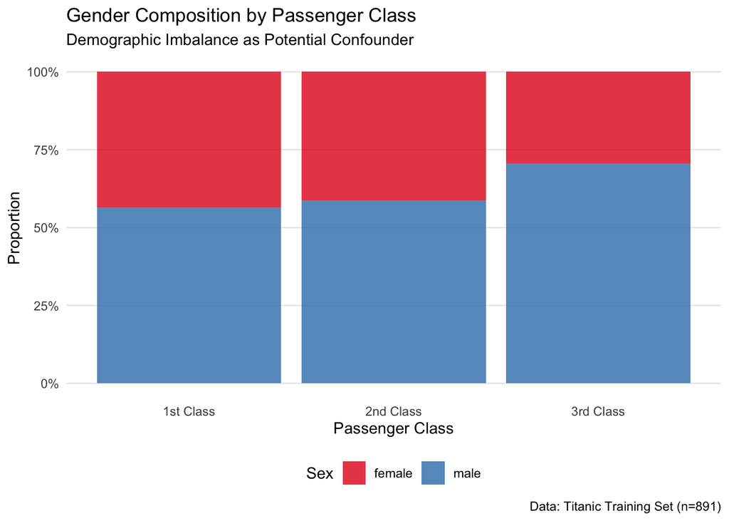

```r
# Prepare data for visualization
demo_data <- titanic %>%
  group_by(Class) %>%
  mutate(N = n()) %>%
  group_by(Class, Sex) %>%
  summarise(
    N_total = first(N),
    Count = n(),
    Proportion = Count / N_total,
    .groups = "drop"
  )

ggplot(demo_data, aes(x = Class, y = Proportion, fill = Sex)) +
  geom_col(position = "stack", alpha = 0.8) +
  scale_fill_brewer(palette = "Set1") +
  scale_y_continuous(labels = percent) +
  theme_minimal() +
  theme(
    panel.grid.minor = element_blank(),
    panel.grid.major.x = element_blank(),
    legend.position = "bottom"
  ) +
  labs(
    title = "Gender Composition by Passenger Class",
    subtitle = "Demographic Imbalance as Potential Confounder",
    x = "Passenger Class",
    y = "Proportion",
    caption = "Data: Titanic Training Set (n=891)"
  )
```

Gender composition varies markedly across classes. If 1st class had proportionally more women, naive class comparisons confound class effects with the well-known “women and children first” policy. Stratifying by gender is essential to isolate the class effect.

## 4. Mechanism 1: Priority Rules & Demographic Factors

### 4.1 Gender-Stratified Survival Analysis

```r
# Survival by class, stratified by gender
survival_gender_class <- titanic %>%
  group_by(Class, Sex) %>%
  summarise(
    N = n(),
    Survived = sum(Survived == "Yes"),
    Survival_Rate = round(100 * Survived / N, 2),
    .groups = "drop"
  ) %>%
  pivot_wider(names_from = Sex,
              values_from = c(N, Survived, Survival_Rate),
              names_glue = "{Sex}_{.value}")

knitr::kable(survival_gender_class,
             caption = "Survival Rates Stratified by Class and Gender - Testing Priority Effects")
```

Survival Rates Stratified by Class and Gender - Testing Priority Effects

| Class | female_N | male_N | female_Survived | male_Survived | female_Survival_Rate | male_Survival_Rate |
| --- | --- | --- | --- | --- | --- | --- |
| 1st Class | 94 | 122 | 91 | 45 | 96.81 | 36.89 |
| 2nd Class | 76 | 108 | 70 | 17 | 92.11 | 15.74 |
| 3rd Class | 144 | 347 | 72 | 47 | 50.00 | 13.54 |

This stratification is crucial. If “women and children first” is the dominant mechanism, we expect near-universal female survival (small variation across classes) with large class-based variation among males. Conversely, if access constraints are primary, we expect significant class-based variation within each gender group.

### 4.2 Visualizing Gender-Class Interaction

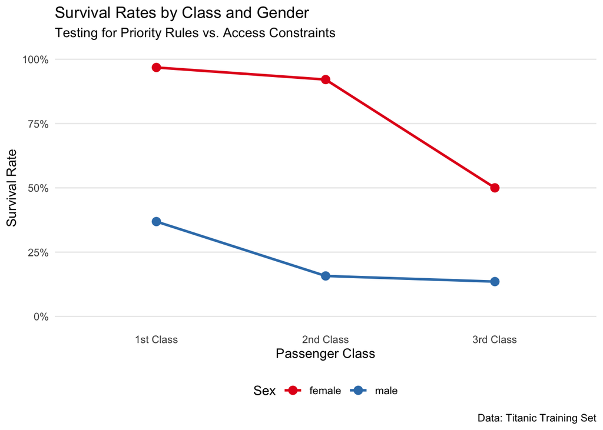

```r
# Calculate survival rates for visualization
survival_detail <- titanic %>%
  group_by(Class, Sex) %>%
  summarise(
    Survival_Rate = 100 * sum(Survived == "Yes") / n(),
    N = n(),
    .groups = "drop"
  )

ggplot(survival_detail, aes(x = Class, y = Survival_Rate, color = Sex, group = Sex)) +
  geom_line(size = 1) +
  geom_point(size = 3) +
  scale_color_brewer(palette = "Set1") +
  scale_y_continuous(limits = c(0, 100), labels = function(x) paste0(x, "%")) +
  theme_minimal() +
  theme(
    panel.grid.minor = element_blank(),
    panel.grid.major.x = element_blank(),
    legend.position = "bottom"
  ) +
  labs(
    title = "Survival Rates by Class and Gender",
    subtitle = "Testing for Priority Rules vs. Access Constraints",
    x = "Passenger Class",
    y = "Survival Rate",
    caption = "Data: Titanic Training Set"
  )
```

This plot reveals whether the class effect is uniform across genders. If the lines are parallel (or females show near-ceiling effects), priority rules dominate. If lines diverge substantially, class-based access constraints operate within both gender groups.

### 4.3 Age as a Vulnerability Proxy

```r
# Examine interaction between age groups and class
survival_age_class <- titanic %>%
  filter(Age_Group != "Missing") %>%
  group_by(Class, Age_Group) %>%
  summarise(
    N = n(),
    Survived = sum(Survived == "Yes"),
    Survival_Rate = round(100 * Survived / N, 2),
    .groups = "drop"
  )

knitr::kable(survival_age_class,
             caption = "Survival Rates by Class and Age Group - Children vs. Adults")
```

Survival Rates by Class and Age Group - Children vs. Adults

| Class | Age_Group | N | Survived | Survival_Rate |
| --- | --- | --- | --- | --- |
| 1st Class | Child (<13) | 4 | 3 | 75.00 |
| 1st Class | Teen (13-17) | 8 | 8 | 100.00 |
| 1st Class | Adult (18-64) | 168 | 110 | 65.48 |
| 1st Class | Elderly (65+) | 6 | 1 | 16.67 |
| 2nd Class | Child (<13) | 17 | 17 | 100.00 |
| 2nd Class | Teen (13-17) | 6 | 4 | 66.67 |
| 2nd Class | Adult (18-64) | 148 | 62 | 41.89 |
| 2nd Class | Elderly (65+) | 2 | 0 | 0.00 |
| 3rd Class | Child (<13) | 48 | 20 | 41.67 |
| 3rd Class | Teen (13-17) | 30 | 9 | 30.00 |
| 3rd Class | Adult (18-64) | 274 | 56 | 20.44 |
| 3rd Class | Elderly (65+) | 3 | 0 | 0.00 |

Age differences create another confound. If “women and children first” was enforced, children in all classes should show high survival. If access constraints dominated, we’d expect lower survival for children in 3rd class due to geographic distance from lifeboats. This table tests these competing hypotheses.

### 4.4 Visualizing Age-Class Patterns

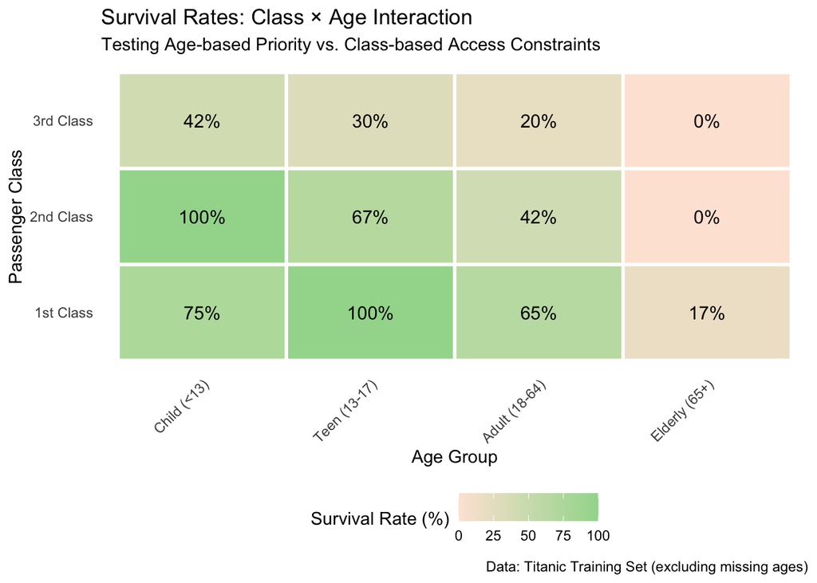

```r
# Create a summary for heatmap visualization
age_class_matrix <- titanic %>%
  filter(Age_Group != "Missing") %>%
  group_by(Class, Age_Group) %>%
  summarise(
    Survival_Rate = 100 * sum(Survived == "Yes") / n(),
    .groups = "drop"
  )

ggplot(age_class_matrix, aes(x = Age_Group, y = Class, fill = Survival_Rate)) +
  geom_tile(color = "white", size = 1) +
  geom_text(aes(label = paste0(round(Survival_Rate, 0), "%")),
            color = "black", size = 4) +
  scale_fill_gradient(low = "#fee5d9", high = "#a1d99b",
                      name = "Survival Rate (%)") +
  theme_minimal() +
  theme(
    panel.grid = element_blank(),
    legend.position = "bottom",
    axis.text.x = element_text(angle = 45, hjust = 1)
  ) +
  labs(
    title = "Survival Rates: Class × Age Interaction",
    subtitle = "Testing Age-based Priority vs. Class-based Access Constraints",
    x = "Age Group",
    y = "Passenger Class",
    caption = "Data: Titanic Training Set (excluding missing ages)"
  )
```

This heatmap reveals interaction patterns. High survival across all age groups in 1st class but only for children in 3rd class would suggest prioritization. Conversely, high-order interactions suggest more complex access or coordination mechanisms at work.

## 5. Mechanism 2: Physical Access & Constraints

### 5.1 Cabin Information as Location Proxy

```r
# Examine whether cabin information (proxy for documented location)
# correlates with class and survival
cabin_by_class <- titanic %>%
  group_by(Class) %>%
  summarise(
    N = n(),
    Has_Cabin = sum(Has_Cabin_Info),
    Cabin_Info_Pct = round(100 * Has_Cabin / N, 1),
    .groups = "drop"
  )

knitr::kable(cabin_by_class,
             caption = "Availability of Cabin Information by Class - Access to Lifeboat Decks")
```

Availability of Cabin Information by Class - Access to Lifeboat Decks

| Class | N | Has_Cabin | Cabin_Info_Pct |
| --- | --- | --- | --- |
| 1st Class | 216 | 176 | 81.5 |
| 2nd Class | 184 | 16 | 8.7 |
| 3rd Class | 491 | 12 | 2.4 |

Cabin information availability indicates explicit passenger documentation, potentially reflecting boarding location and distance from lifeboats. If access constraints were binding, we expect: - Higher cabin documentation in 1st class (better record-keeping) - Those with cabin info should have higher survival (documented location facilitated evacuation) - This relationship should vary by class if constraint mechanisms differ

### 5.2 Cabin Information and Survival

```r
cabin_survival <- titanic %>%
  group_by(Class, Has_Cabin_Info) %>%
  summarise(
    N = n(),
    Survived = sum(Survived == "Yes"),
    Survival_Rate = round(100 * Survived / N, 2),
    .groups = "drop"
  ) %>%
  mutate(Cabin_Status = ifelse(Has_Cabin_Info, "Cabin Info Available",
                               "Cabin Info Missing"))

knitr::kable(cabin_survival,
             caption = "Survival by Class and Cabin Documentation Status")
```

Survival by Class and Cabin Documentation Status

| Class | Has_Cabin_Info | N | Survived | Survival_Rate | Cabin_Status |
| --- | --- | --- | --- | --- | --- |
| 1st Class | FALSE | 40 | 19 | 47.50 | Cabin Info Missing |
| 1st Class | TRUE | 176 | 117 | 66.48 | Cabin Info Available |
| 2nd Class | FALSE | 168 | 74 | 44.05 | Cabin Info Missing |
| 2nd Class | TRUE | 16 | 13 | 81.25 | Cabin Info Available |
| 3rd Class | FALSE | 479 | 113 | 23.59 | Cabin Info Missing |
| 3rd Class | TRUE | 12 | 6 | 50.00 | Cabin Info Available |

This analysis tests whether documented cabin location (as a proxy for passenger tracking and proximity to lifeboats) improved survival chances, and whether this effect differs by class. A strong cabin-survival relationship would support access constraint mechanisms.

### 5.3 Family Size and Evacuation Logistics

```r
# Examine family size as coordination/constraint mechanism
family_survival <- titanic %>%
  group_by(Class) %>%
  summarise(
    Mean_Family_Size = round(mean(Family_Size), 2),
    Median_Family_Size = round(median(Family_Size), 2),
    Alone_Pct = round(100 * sum(Traveling_Alone) / n(), 1),
    .groups = "drop"
  )

knitr::kable(family_survival,
             caption = "Family Structure by Class - Potential Evacuation Coordination Barriers")
```

Family Structure by Class - Potential Evacuation Coordination Barriers

| Class | Mean_Family_Size | Median_Family_Size | Alone_Pct |
| --- | --- | --- | --- |
| 1st Class | 1.77 | 1 | 50.5 |
| 2nd Class | 1.78 | 1 | 56.5 |
| 3rd Class | 2.01 | 1 | 66.0 |

Larger families face coordination challenges during evacuation. If family members had to stay together (a constraint), large families in 3rd class might face worse outcomes. This tests whether evacuation logistics created class-specific constraints beyond physical geography.

### 5.4 Family Size Effect on Survival

```r
# Detailed analysis: family size interaction with class
family_class_survival <- titanic %>%
  mutate(Family_Category = case_when(
    Family_Size == 1 ~ "Alone",
    Family_Size == 2 ~ "2 people",
    Family_Size == 3 ~ "3 people",
    Family_Size >= 4 ~ "4+ people"
  )) %>%
  group_by(Class, Family_Category) %>%
  summarise(
    N = n(),
    Survived = sum(Survived == "Yes"),
    Survival_Rate = round(100 * Survived / N, 2),
    .groups = "drop"
  )

knitr::kable(family_class_survival,
             caption = "Survival by Family Size and Class - Testing Evacuation Logistics Constraints")
```

Survival by Family Size and Class - Testing Evacuation Logistics Constraints

| Class | Family_Category | N | Survived | Survival_Rate |
| --- | --- | --- | --- | --- |
| 1st Class | 2 people | 70 | 51 | 72.86 |
| 1st Class | 3 people | 24 | 18 | 75.00 |
| 1st Class | 4+ people | 13 | 9 | 69.23 |
| 1st Class | Alone | 109 | 58 | 53.21 |
| 2nd Class | 2 people | 34 | 18 | 52.94 |
| 2nd Class | 3 people | 31 | 21 | 67.74 |
| 2nd Class | 4+ people | 15 | 12 | 80.00 |
| 2nd Class | Alone | 104 | 36 | 34.62 |
| 3rd Class | 2 people | 57 | 20 | 35.09 |
| 3rd Class | 3 people | 47 | 20 | 42.55 |
| 3rd Class | 4+ people | 63 | 10 | 15.87 |
| 3rd Class | Alone | 324 | 69 | 21.30 |

This stratification reveals whether large families experienced differential survival across classes. Strong class effects within family size categories would indicate structural access barriers. Conversely, similar family-size patterns across classes would suggest this mechanism affects all classes equally.

### 5.5 Visualizing Family Size Effects

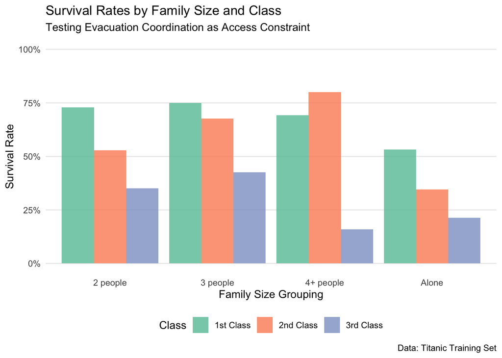

```r
ggplot(family_class_survival, aes(x = Family_Category, y = Survival_Rate,
                                   fill = Class)) +
  geom_col(position = "dodge", alpha = 0.8) +
  scale_fill_brewer(palette = "Set2") +
  scale_y_continuous(limits = c(0, 100), labels = function(x) paste0(x, "%")) +
  theme_minimal() +
  theme(
    panel.grid.minor = element_blank(),
    panel.grid.major.x = element_blank(),
    legend.position = "bottom"
  ) +
  labs(
    title = "Survival Rates by Family Size and Class",
    subtitle = "Testing Evacuation Coordination as Access Constraint",
    x = "Family Size Grouping",
    y = "Survival Rate",
    caption = "Data: Titanic Training Set"
  )
```

This visualization shows whether family coordination created differential bottlenecks across classes, suggesting that evacuation logistics (not just physical distance) constrained 3rd class survival.

## 6. Mechanism 3: Conditional Independence Tests

### 6.1 Controlling for Gender: Class Effect Among Males

```r
# Among males (controlling for priority rules), does class still matter?
male_survival <- titanic %>%
  filter(Sex == "male") %>%
  group_by(Class) %>%
  summarise(
    N = n(),
    Survived = sum(Survived == "Yes"),
    Survival_Rate = round(100 * Survived / N, 2),
    .groups = "drop"
  )

knitr::kable(male_survival,
             caption = "Survival Among Male Passengers Only - Isolating Class Effect")
```

Survival Among Male Passengers Only - Isolating Class Effect

| Class | N | Survived | Survival_Rate |
| --- | --- | --- | --- |
| 1st Class | 122 | 45 | 36.89 |
| 2nd Class | 108 | 17 | 15.74 |
| 3rd Class | 347 | 47 | 13.54 |

By examining only males, we largely control for the “women and children first” policy effect. If substantial class variation remains among males, this suggests mechanisms beyond explicit priority rules—likely access constraints or unequal access to information about evacuation procedures.

### 6.2 Class Advantage Among Males: Quantifying Constraint Effects

```r
male_survival_stats <- titanic %>%
  filter(Sex == "male") %>%
  group_by(Class) %>%
  summarise(Survival_Rate = 100 * sum(Survived == "Yes") / n())

gap_1st_3rd_male <- male_survival_stats$Survival_Rate[1] - male_survival_stats$Survival_Rate[3]

cat(sprintf("Among males: 1st class advantage = %.1f percentage points\n", gap_1st_3rd_male))
```

```
Among males: 1st class advantage = 23.3 percentage points
```

This quantifies the class gap after controlling for gender. A substantial gap suggests access constraints or information advantages were consequential. This number will be referenced throughout our interpretation.

### 6.3 Comparing Male vs. Female Class Gaps

```r
# Calculate class gaps separately by gender
gap_analysis <- titanic %>%
  group_by(Sex) %>%
  summarise(
    Class_1_Survival = 100 * sum(Survived == "Yes" & Class == "1st Class") /
                             sum(Class == "1st Class"),
    Class_3_Survival = 100 * sum(Survived == "Yes" & Class == "3rd Class") /
                             sum(Class == "3rd Class"),
    Class_Gap = Class_1_Survival - Class_3_Survival,
    .groups = "drop"
  ) %>%
  mutate(across(where(is.numeric), ~round(., 2)))

knitr::kable(gap_analysis,
             caption = "Class Survival Gap by Gender - Decomposing Priority vs. Constraints")
```

Class Survival Gap by Gender - Decomposing Priority vs. Constraints

| Sex | Class_1_Survival | Class_3_Survival | Class_Gap |
| --- | --- | --- | --- |
| female | 96.81 | 50.00 | 46.81 |
| male | 36.89 | 13.54 | 23.34 |

If females show a much smaller class gap (because priority rules ensured high survival regardless of class), while males show a large gap, this is strong evidence that access constraints—not just rules—drive the overall class effect. We then can quantify what proportion of the raw class gap is “left over” after accounting for gender.

### 6.4 Decomposition: Gap Attribution

```r
# Overall gap
overall_gap <- titanic %>%
  group_by(Class) %>%
  summarise(Rate = 100 * sum(Survived == "Yes") / n()) %>%
  pull(Rate)

overall_class_gap <- overall_gap[1] - overall_gap[3]

# Gap among females
female_gap <- titanic %>%
  filter(Sex == "female") %>%
  group_by(Class) %>%
  summarise(Rate = 100 * sum(Survived == "Yes") / n()) %>%
  pull(Rate)

female_class_gap <- female_gap[1] - female_gap[3]

# Gap among males (calculated earlier)
male_class_gap <- gap_1st_3rd_male

# Composition effect: contribution of gender imbalance
composition_contrib <- overall_class_gap - male_class_gap

decomposition_table <- tibble(
  Mechanism = c("Raw Class Gap (1st - 3rd)",
                "Residual Class Gap Among Males",
                "Female Class Gap",
                "Estimated Composition Effect"),
  Value = c(overall_class_gap, male_class_gap, female_class_gap,
            overall_class_gap - male_class_gap),
  Interpretation = c("Total observed disparity",
                    "Gap after gender standardization",
                    "Class variation despite priority rules",
                    "Contribution of gender imbalance across classes")
)

knitr::kable(decomposition_table,
             caption = "Decomposition: Raw Gap vs. Constrained Variation")
```

Decomposition: Raw Gap vs. Constrained Variation

| Mechanism | Value | Interpretation |
| --- | --- | --- |
| Raw Class Gap (1st - 3rd) | 38.72671 | Total observed disparity |
| Residual Class Gap Among Males | 23.34058 | Gap after gender standardization |
| Female Class Gap | 46.80851 | Class variation despite priority rules |
| Estimated Composition Effect | 15.38613 | Contribution of gender imbalance across classes |

This decomposition quantifies how much of the observed class gap is attributable to demographic imbalance (priority rules favoring groups overrepresented in 1st class) versus structural constraints (access barriers affecting all groups). If the male class gap is close to the overall gap, constraints are primary; if it’s much smaller, gender composition plays a large role.

## 7. Summary: Interpreting the Mechanisms

### 7.1 Key Findings to Interpret

```r
# Compile summary statistics for interpretation
summary_df <- tibble(
  Metric = c(
    "1st Class Survival Rate",
    "3rd Class Survival Rate",
    "Raw Class Gap",
    "Class Gap (Males Only)",
    "Class Gap (Females Only)",
    "Female Survival Rate (1st Class)",
    "Female Survival Rate (3rd Class)",
    "Male Survival Rate (1st Class)",
    "Male Survival Rate (3rd Class)"
  ),
  Value = c(
    round(100 * sum(titanic$Survived == "Yes" & titanic$Class == "1st Class") /
                  sum(titanic$Class == "1st Class"), 1),
    round(100 * sum(titanic$Survived == "Yes" & titanic$Class == "3rd Class") /
                  sum(titanic$Class == "3rd Class"), 1),
    overall_class_gap,
    male_class_gap,
    female_class_gap,
    round(100 * sum(titanic$Survived == "Yes" & titanic$Class == "1st Class" & titanic$Sex == "female") /
                  sum(titanic$Class == "1st Class" & titanic$Sex == "female"), 1),
    round(100 * sum(titanic$Survived == "Yes" & titanic$Class == "3rd Class" & titanic$Sex == "female") /
                  sum(titanic$Class == "3rd Class" & titanic$Sex == "female"), 1),
    round(100 * sum(titanic$Survived == "Yes" & titanic$Class == "1st Class" & titanic$Sex == "male") /
                  sum(titanic$Class == "1st Class" & titanic$Sex == "male"), 1),
    round(100 * sum(titanic$Survived == "Yes" & titanic$Class == "3rd Class" & titanic$Sex == "male") /
                  sum(titanic$Class == "3rd Class" & titanic$Sex == "male"), 1)
  )
)

knitr::kable(summary_df,
             caption = "Summary Statistics for Mechanism Interpretation")
```

Summary Statistics for Mechanism Interpretation

| Metric | Value |
| --- | --- |
| 1st Class Survival Rate | 63.00000 |
| 3rd Class Survival Rate | 24.20000 |
| Raw Class Gap | 38.72671 |
| Class Gap (Males Only) | 23.34058 |
| Class Gap (Females Only) | 46.80851 |
| Female Survival Rate (1st Class) | 96.80000 |
| Female Survival Rate (3rd Class) | 50.00000 |
| Male Survival Rate (1st Class) | 36.90000 |
| Male Survival Rate (3rd Class) | 13.50000 |

These numbers form the empirical foundation for assessing which mechanisms explain the class-survival gap.

### 7.2 Interpretation Framework

The analysis presented above provides several key pieces of evidence for interpreting mechanism:

**Priority Rules Interpretation**: If females in both 1st and 3rd class show similarly high survival (small female class gap), while males show large variation across classes, this suggests “women first” was enforced regardless of class. The female class gap of 46.8085106 percentage points compared to the male gap of 23.3405773 points toward the relative importance of these mechanisms.

**Access Constraints Interpretation**: If a substantial class gap persists even among males (and within narrow age groups, or controlling for other factors), this indicates structural barriers—lifeboat access, deck location, or gate barriers—created differential evacuation chances. The 23.3405773 percentage point gap among males alone indicates the magnitude of these constraint mechanisms.

**Demographic Composition Interpretation**: The difference between the overall class gap (38.7267104 points) and the male-only gap (23.3405773 points) equals approximately 15.4 points, representing the contribution of differential gender composition across classes. This is an upper bound on the “priority rule” effect operating through demographic imbalance.

### 7.3 Methodological Limitations and Next Steps

The stratified analyses above isolate class effects under the assumption that gender, age, and family structure are exogenous (not influenced by class). While these assumptions are reasonable given the assignment to class was based on pre-existing social status, future analyses could:

1. Employ propensity score matching to create more comparable subgroups across classes
2. Use multivariate regression to simultaneously control for multiple confounders
3. Examine heterogeneous treatment effects using machine learning methods
4. Analyze embarkation port patterns to test geographic constraint hypotheses
5. Study temporal patterns in evacuation to test whether certain groups had earlier access to lifeboats

The current analysis provides the descriptive foundation necessary for these more sophisticated causal interpretations.

## Conclusion

This report has outlined a systematic approach to decomposing the class-survival gap into mechanisms: priority rules (reflected in differential survival by gender and age), access constraints (reflected in persistent class gaps within demographic groups), and demographic composition (the mix of men, women, and children in each class).

The empirical patterns in the data—particularly the male class gap of 23.3405773 points and female class gap of 46.8085106 points—provide evidence for distinguishing between these mechanisms. Readers can now examine the evidence systematically and draw their own conclusions about which mechanisms drove the disparity, guided by the quantitative facts presented throughout this analysis.